# Aiding a City after a Natural Disaster: An Optimization Problem

*Imagine that you in charge of the Operations Research division of a humanitarian organization, specialized in providing a fast response in assisting the population after a natural disaster. Identify and describe an optimization problem that may contribute to improve this organization response (food logistics, infrastructure reconstruction, vaccination programs, etc.,), where the decision-making process requires the formulation of a (continuous) linear optimization problem (LP) with at least 100 decision variables and 20 constraints. You should not use any of the models described in class or in the slides (but a significant modification of any of them might be acceptable).*

**Our case**:

Unfortunately, we have once again seen the effects of the floods in the Valencia region. The floods of October 2024 have caused enormous damage in many towns in the province of Valencia, but not in the capital. Why?

In 1957, Valencia experienced one of its worst floods, but it was the last one. As a result of this catastrophe, the course of the Turia, its river, was diverted, thus avoiding future floods, including this year's. Now, the people of the affected localities need this type of works to be able to continue living peacefully.

We are going to make a model that simulates what would have happened if the new Turia riverbed had never been created and we had to provide help to the 16 districts of Valencia.

## a) Formulation of the problem

*Formulate mathematically the problem as a linear optimization model (based on the general formulation of an LP). Identify the model sets, parameters, variables, objective function and constraints.*

This model is going to use data that would be available before the natural disaster about the risk of each zone and data collected after the disaster about necessities. This allows us to make a more precise model in the time between natural disasters but also to take into account how it has affected the different zones.

### Model sets

Model sets are going to be the 16 districts of Valencia and 7 types of supply. This could be easily adapted to different cities (or zones) and supplies.

- Districts of Valencia ($i$):
  1. Algirós
  2. Benicalap
  3. Benimaclet
  4. Camins al grau
  5. Campanar
  6. Ciutat vella
  7. El pla del real
  8. Extramurs
  9. Jesus
  10. L'eixample
  11. L'olivereta
  12. La saïdia
  13. Patraix
  14. Poblats marítims
  15. Quatre carreres
  16. Rascanya
- Types of supply ($j$):
  1. Medical & Hygiene Supplies
  2. Tools & Equipment
  3. Food & Nutrition
  4. Water & Water purification
  5. Clothing & Personal Protection
  6. Power & Communication
  7. Child & Elderly Care

### Variables and parameters

Our data will mix real data from the city of Valencia and random data created based in the real world. This random data will always be created using a random.seed, so the dataset can be retrieved and the results reproduced.

- $x_{ij}$: tons of supply $j$ sent to district $i$. These will be our **decision variables**.
- $v_i$: vulnerability index of the district $i$ of Valencia in the year 2021. It supports users to assess a community’s vulnerability to climate hazards and impacts such as flooding, extreme heat and drought events. The mapped outputs can be used to inform decision-making on climate adaptation and resilience building. These values are calculated from https://valencia.opendatasoft.com/explore/dataset/vulnerabilidad-por-barrios/table/.
- $p_{ij}$: priority index for supply $j$ in district $i$. It will assign a random number in a subrange between the range [0, 1]. This subrange will be assigned depending on the severity that the flooding of 1957 had in the different districts in Valencia: very low (0), low (1), medium (2), high (3). We can suppose what the severity would have been in the newer districts by checking their proximity to the river Turia. In a real case, a simple formulary sent to the district governors could provide us this information.
- $S_j$: available tons of supply $j$.
- $C_i$: capacity of storage for tons of supplies for district $i$.
- $R_{ij}$: minimum tons of supply $j$ required by district $i$.
- $t_i$: time of transport by ton of supply for district $i$.
- $L_i$: limit of total time of transportation for district $i$.

### Objective function

Our objective will be to maximize the following expression:

$$ \max \sum_{i=1}^m v_i^2 \sum_{j=1}^n p_{ij}x_{ij} $$

where we square the vulnerability index to increase its relevance. Maximizing this function will tend to assign more supplies to those districts that require it and those that are more vulnerable or have been the most affected.

### Constraints

These constraints can be adapted to several types of real life situations, which makes our model very flexible.

- **Non-negativity of the decision variables**: $ x_{ij} \in \mathbb{R}_{\ge 0} $
- **Limit of supplies**: $ \sum_{i=1}^m x_{ij} \le S_j $. There is a total amount of supply $j$, so we cannot excede that limit.
- **Supply capacity**: $ \sum_{j=1}^n x_{ij} \le C_i $. Each district has a limit of capacity for storing supplies.
- **Minimum supplies required**: $ x_{ij} \ge R_{ij} $. Some districts have asked for a minimum amount of supplies that we have to provide.
- **Time limit**: $ t_i \sum_{j=1}^n x_{ij} \le L_i $. Time taken to deliver a ton of supply and time limit varies between district, and we cannot excede it.
- **Linked supplies**: $ x_{i3} = x_{i4} \ \rightarrow \ x_{i3} - x_{i4} = 0 $. Supplies 3 and 4 are transported always together, so tons transported have to be equal
- **Proportion of supply**: $ x_{i6} \le 0.5 \sum_{j=1}^n x_{ij} \ \rightarrow \ x_{i6} - 0.5 \sum_{j=1}^n x_{ij} <= 0 $. Quantity of supply 6 cannot excede half of the quantity of total supplies in each district.

## b) Implementation and solution in Pyomo

*Implement the model in Pyomo and solve it for a set of (parameter) values, either based on real-world or randomly generated data (make sure that the values you use are coherent with the model defined in a)). In both cases, include your model and the specific data you have used.*

First, we import the libraries that we will use through all the problem.

```python
from pyomo.environ import *
import random
import pandas as pd
import time
import matplotlib.pyplot as plt
import seaborn as sns
from matplotlib.patches import Patch
import numpy as np

pd.set_option("display.precision", 2)  # Use two decimal places for easier to read results.
```

Select the random.seed, the size of our problem (16 districts, 7 supply types) and the data that we have obtained:

```python
random.seed(42)
m = 16  # Number of districts
n = 7  # Number of supply types

districts = ["ALGIRÓS", "BENICALAP", "BENIMACLET", "CAMINS AL GRAU", "CAMPANAR", "CIUTAT VELLA", "EL PLA DEL REAL", "EXTRAMURS", "JESUS", "L'EIXAMPLE", "L'OLIVERETA", "LA SAÏDIA", "PATRAIX", "POBLATS MARÍTIMS", "QUATRE CARRERES", "RASCANYA"]
vulnerability_indexes = [2.78, 2.85, 3, 2.72, 3.05, 2.95, 2.925, 2.925, 2.6, 3.03, 2.48, 2.54, 2.9, 2.68, 2.72, 3]
severities_per_district = [1, 2, 2, 3, 2, 3, 3, 3, 1, 3, 1, 2, 1, 3, 2, 0]
```

Generate the data based in real information and within reasonable ranges:

```python
v = {i: vulnerability_indexes[i-1] for i in range(1, m + 1)}
p = {
    (i, j): (
        random.uniform(0, 0.1) if severities_per_district[i-1] == 0 else
        random.uniform(0.1, 0.3) if severities_per_district[i-1] == 1 else
        random.uniform(0.3, 0.6) if severities_per_district[i-1] == 2 else
        random.uniform(0.6, 1)
    )
    for i in range(1, m + 1)
    for j in range(1, n + 1)
}

S = {j: random.randint(100, 5000) for j in range(1, n + 1)}
C = {i: random.randint(200, 2000) for i in range(1, m + 1)}
R = {(i, j): random.randint(0, 20) for i in range(1, m + 1) for j in range(1, n + 1)}
t = {i: random.uniform(0.1, 10) for i in range(1, m + 1)}
L = {i: random.randint(500, 2000) for i in range(1, m + 1)}
```

We can see what the $p_{ij}$ that was generated looks like. Notice the extreme case of zone 16 (Rascanya), where priority is very low. Rascanya is the district that is the most far from the Turia, so it would not be affected by this hypothetical flooding.

```python
view_p = []
for i in range(1, m+1):
    for j in range(1, n+1):
        view_p.append({'District': i, 'Supply': j, 'p_ij': p[i, j]})
view_p_df = pd.DataFrame(view_p)
pivot_view_p_df = view_p_df.pivot(index='District', columns='Supply', values='p_ij')
pivot_view_p_df
```

| Supply District | 1 | 2 | 3 | 4 | 5 | 6 | 7 |
| --- | --- | --- | --- | --- | --- | --- | --- |
| 1 | 0.23 | 0.11 | 0.16 | 0.14 | 0.25 | 0.24 | 0.28 |
| 2 | 0.33 | 0.43 | 0.31 | 0.37 | 0.45 | 0.31 | 0.36 |
| 3 | 0.49 | 0.46 | 0.37 | 0.48 | 0.54 | 0.30 | 0.54 |
| 4 | 0.88 | 0.74 | 0.66 | 0.98 | 0.73 | 0.64 | 0.64 |
| 5 | 0.55 | 0.48 | 0.54 | 0.52 | 0.46 | 0.59 | 0.41 |
| 6 | 0.82 | 0.93 | 0.85 | 0.94 | 0.83 | 0.88 | 0.62 |
| 7 | 0.69 | 0.72 | 0.63 | 0.69 | 0.64 | 0.71 | 0.85 |
| 8 | 0.75 | 0.75 | 0.68 | 0.71 | 0.97 | 0.86 | 0.84 |
| 9 | 0.13 | 0.25 | 0.13 | 0.18 | 0.30 | 0.23 | 0.21 |
| 10 | 0.87 | 0.94 | 0.91 | 0.69 | 0.61 | 0.73 | 0.71 |
| 11 | 0.14 | 0.29 | 0.28 | 0.16 | 0.23 | 0.18 | 0.28 |
| 12 | 0.44 | 0.38 | 0.37 | 0.47 | 0.38 | 0.48 | 0.57 |
| 13 | 0.18 | 0.14 | 0.30 | 0.20 | 0.12 | 0.11 | 0.12 |
| 14 | 0.85 | 0.92 | 0.77 | 0.63 | 0.75 | 1.00 | 0.81 |
| 15 | 0.59 | 0.56 | 0.30 | 0.52 | 0.50 | 0.46 | 0.38 |
| 16 | 0.06 | 0.01 | 0.04 | 0.05 | 0.10 | 0.09 | 0.03 |

We can visualize more clearly the priorities with a heatmap:

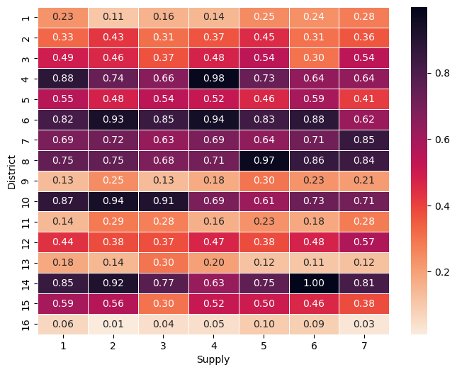

```python
plt.figure(figsize=(8, 6))
sns.heatmap(pivot_view_p_df, linewidths=0.5, annot=True, fmt=".2f", cmap='rocket_r')
```

As district 16 has not be affected, we assign that they do not require a minimum amount of supplies:

```python
for key in list(R.keys()):
    if key[0] == 16:
        R[key] = 0
```

Create the model:

```python
# Model
model = ConcreteModel()

# Sets
model.DISTRICTS = Set(initialize=range(1, m + 1))
model.SUPPLIES = Set(initialize=range(1, n + 1))

# Parameters
model.v = Param(model.DISTRICTS, initialize=v)
model.p = Param(model.DISTRICTS, model.SUPPLIES, initialize=p)

model.S = Param(model.SUPPLIES, initialize=S)
model.C = Param(model.DISTRICTS, initialize=C)
model.R = Param(model.DISTRICTS, model.SUPPLIES, initialize=R)
model.t = Param(model.DISTRICTS, initialize=t)
model.L = Param(model.DISTRICTS, initialize=L)

# Decision variables
model.x = Var(model.DISTRICTS, model.SUPPLIES, domain=NonNegativeReals)
```

Implement the objective function and the constraints:

```python
# Objective function
def objective_rule(model):
    return sum((model.v[i])**2 * sum(model.p[i, j] * model.x[i, j] for j in model.SUPPLIES) for i in model.DISTRICTS)
model.OBJ = Objective(rule=objective_rule, sense=maximize)
```

```python
# Constraint 1: Supply availability (of the supply j)
def supply_availability_rule(model, j):
    return sum(model.x[i, j] for i in model.DISTRICTS) <= model.S[j]
model.SupplyConstraint = Constraint(model.SUPPLIES, rule=supply_availability_rule)

# Constraint 2: Zone capacity for supplies (for the zone i)
def zone_capacity_rule(model, i):
    return sum(model.x[i, j] for j in model.SUPPLIES) <= model.C[i]
model.CapacityConstraint = Constraint(model.DISTRICTS, rule=zone_capacity_rule)

# Constraint 3: Minimum required supply (for the zone i and the supply j)
def min_required_supply_rule(model, i, j):
    return model.x[i, j] >= model.R[i, j]
model.MinRequiredSupplyConstraint = Constraint(model.DISTRICTS, model.SUPPLIES, rule=min_required_supply_rule)

# Constraint 4: Limit of time (for zone i)
def time_limit_rule(model, i):
    return model.t[i] * sum(model.x[i, j] for j in model.SUPPLIES) <= model.L[i]
model.TimeConstraint = Constraint(model.DISTRICTS, rule=time_limit_rule)

# Constraint 5: Linked supplies (supplies 3 and 4, for each zone i)
def linked_supplies_rule(model, i):
    return model.x[i, 3] == model.x[i, 4]
model.LinkedSupplies = Constraint(model.DISTRICTS, rule=linked_supplies_rule)

# Constraint 6: Proportion of supply (supply 6, for each zone i)
def proportion_supply_rule(model, i):
    return model.x[i, 6] <= 0.5 * (sum(model.x[i, j] for j in model.SUPPLIES))
model.ProportionSupply = Constraint(model.DISTRICTS, rule=proportion_supply_rule)
```

Solve the model using GLPK and getting the dual values (we will use them in the following parts):

```python
model.dual = Suffix(direction=Suffix.IMPORT)
solver = SolverFactory('glpk')  # Use GLPK as the solver
results = solver.solve(model, tee=True)
print(f'Objective function value: {value(model.OBJ)}.')
```

```
GLPSOL--GLPK LP/MIP Solver 5.0
Parameter(s) specified in the command line:
 --write /var/folders/8g/6pyhwxxx6y147q2dm10zjk1w0000gn/T/tmp8dx4y3tf.glpk.raw
 --wglp /var/folders/8g/6pyhwxxx6y147q2dm10zjk1w0000gn/T/tmpmhj5ylff.glpk.glp
 --cpxlp /var/folders/8g/6pyhwxxx6y147q2dm10zjk1w0000gn/T/tmpahhrno7p.pyomo.lp
Reading problem data from '/var/folders/8g/6pyhwxxx6y147q2dm10zjk1w0000gn/T/tmpahhrno7p.pyomo.lp'...
183 rows, 112 columns, 592 non-zeros
1374 lines were read
Writing problem data to '/var/folders/8g/6pyhwxxx6y147q2dm10zjk1w0000gn/T/tmpmhj5ylff.glpk.glp'...
1169 lines were written
GLPK Simplex Optimizer 5.0
183 rows, 112 columns, 592 non-zeros
Preprocessing...
71 rows, 112 columns, 480 non-zeros
Scaling...
 A: min|aij| =  5.000e-01  max|aij| =  9.202e+00  ratio =  1.840e+01
Problem data seem to be well scaled
Constructing initial basis...
Size of triangular part is 71
      0: obj =   3.937007751e+03 inf =   6.200e+01 (8)
      8: obj =   4.553563065e+03 inf =   0.000e+00 (0)
*    39: obj =   2.021299206e+04 inf =   0.000e+00 (0)
OPTIMAL LP SOLUTION FOUND
Time used:   0.0 secs
Memory used: 0.2 Mb (227176 bytes)
Writing basic solution to '/var/folders/8g/6pyhwxxx6y147q2dm10zjk1w0000gn/T/tmp8dx4y3tf.glpk.raw'...
304 lines were written
```

```
Objective function value: 20212.99205668889.
```

Check if the solver has found an optimal solution:

```python
if results.solver.status == SolverStatus.ok and results.solver.termination_condition == TerminationCondition.optimal:
    print("Solver found an optimal solution.")
else:
    print("Solver did not find an optimal solution.")
```

```
Solver found an optimal solution.
```

Show the values obtained for our decision variables $x_{ij}$:

```python
data = []
for i in model.DISTRICTS:
    for j in model.SUPPLIES:
        data.append({'District': i, 'Supply': j, 'x_ij': value(model.x[i, j])})
df = pd.DataFrame(data)
pivot_df = df.pivot(index='District', columns='Supply', values='x_ij')
pivot_df
```

| Supply District | 1 | 2 | 3 | 4 | 5 | 6 | 7 |
| --- | --- | --- | --- | --- | --- | --- | --- |
| 1 | 9.00 | 7.00 | 7.0 | 7.0 | 18.00 | 2.00 | 160.67 |
| 2 | 15.00 | 2.00 | 17.0 | 17.0 | 137.12 | 15.00 | 17.00 |
| 3 | 5.00 | 8.00 | 19.0 | 19.0 | 16.56 | 6.00 | 17.00 |
| 4 | 22.03 | 9.00 | 20.0 | 20.0 | 11.00 | 14.00 | 16.00 |
| 5 | 29.10 | 3.00 | 7.0 | 7.0 | 2.00 | 48.10 | 0.00 |
| 6 | 18.00 | 286.33 | 18.0 | 18.0 | 7.00 | 0.00 | 2.00 |
| 7 | 20.00 | 1.00 | 7.0 | 7.0 | 1.00 | 10.00 | 276.73 |
| 8 | 16.00 | 7.00 | 15.0 | 15.0 | 127.00 | 17.00 | 4.00 |
| 9 | 18.00 | 18.00 | 15.0 | 15.0 | 1341.00 | 13.00 | 6.00 |
| 10 | 3.00 | 110.58 | 13.0 | 13.0 | 13.00 | 13.00 | 14.00 |
| 11 | 1.00 | 995.02 | 20.0 | 20.0 | 1.00 | 12.00 | 10.00 |
| 12 | 3.00 | 7.00 | 6.0 | 6.0 | 17.00 | 14.00 | 186.00 |
| 13 | 13.00 | 5.00 | 194.0 | 194.0 | 7.00 | 2.00 | 14.00 |
| 14 | 17.00 | 98.79 | 20.0 | 20.0 | 17.00 | 174.79 | 2.00 |
| 15 | 118.59 | 5.00 | 15.0 | 15.0 | 15.00 | 6.00 | 12.00 |
| 16 | 0.00 | 0.00 | 0.0 | 0.0 | 108.43 | 0.00 | 0.00 |

Visualizing them in a heatmap:

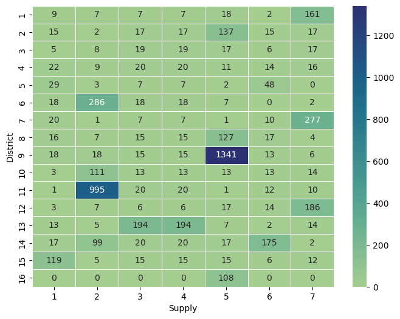

```python
plt.figure(figsize=(8, 6))
sns.heatmap(pivot_df, linewidths=0.5, annot=True, fmt=".0f", cmap="crest")
```

## c) Sensitivities

*Compute the sensitivities associated with each constraint, and interpret the values of those you may consider more important.*

For the sensitivities analysis, we will use the dual values that we retrieved when solving the model. We can print and analyze them:

```python
for constraint in model.component_objects(Constraint, active=True):
    print(f"Dual values for {constraint}:")
    for index in constraint:
        print(f"  {index}: {model.dual[constraint[index]]}")
```

```
Dual values for SupplyConstraint:
  1: 0.0
  2: 0.0
  3: 0.0
  4: 0.0
  5: 0.0
  6: 0.0
  7: 0.0
Dual values for CapacityConstraint:
  1: 0.0
  2: 0.0
  3: 0.0
  4: 0.0
  5: 0.0
  6: 0.0
  7: 0.0
  8: 8.33884116279908
  9: 2.01383557006068
  10: 0.0
  11: 0.0
  12: 3.67319823475492
  13: 2.10844074004429
  14: 0.0
  15: 0.0
  16: 0.0
Dual values for MinRequiredSupplyConstraint:
  (1, 1): -0.390674900369644
  (1, 2): -1.34036549007745
  (1, 3): 0.0
  (1, 4): -1.9879285378614
  (1, 5): -0.240675287900995
  (1, 6): -0.33306325049018
  (1, 7): 0.0
  (2, 1): -1.01957629787614
  (2, 2): -0.203306504167786
  (2, 3): -1.85747453700334
  (2, 4): 0.0
  (2, 5): 0.0
  (2, 6): -1.16676297415871
  (2, 7): -0.746906852975178
```

[output cut: 134 more lines]

```
  2: 0.0
  3: 0.0
  4: 0.0
  5: 0.350577915441256
  6: 0.0
  7: 0.0
  8: 0.0
  9: 0.0
  10: 0.0
  11: 0.0
  12: 0.0
  13: 0.0
  14: 0.586204549934365
  15: 0.0
  16: 0.0
```

**SupplyConstraint:** All dual values are 0, so these constraints are non-binding. There is an excess of supplies, so increasing or decreasing the supply limit will not affect the objective function.

**CapacityConstraint:** There are some districts that could benefit a lot from improving their storage. The two biggest absolute values are:

- $8$: 8.34. This is the biggest value of all constraints, so it is the most critical one: district $8$ urgently needs to increase their capacity for storage.
- $12$: 3.67.

**MinRequiredSupplyConstraint:** There are many non-zero values, which means that the demands from each district are affecting severely the objective function. However, this constraint can be very useful, as it allows us to help those who require supplies directly, so we do not rely entirely on the objective function. The two biggest absolute values are:

- $(8, 4)$: -4.78.
- $(7, 3)$: -3.28.

**TimeConstraint:** There are again some non-zero values, showing us that reducing the time per ton of supply transported would benefit the objective function. The two biggest absolute values are:

- $7$: 3.69.
- $11$: 2.52.

**LinkedSupplies:** There is no zero values in this constraint, showing us its relevance. Not having to deliver these supplies together could bring great benefit and flexibility.

**ProportionSupply:** Most constraints are non-binding (null dual values), except:

- $5$: 0.35.
- $14$: 0.59.

As this is a high number of sensitivities, we want a tool than can scale with bigger problems to extract those that are most important. To do it, we will select the top 10 with the highest absolute value, which show us the most important constraints:

```python
dict_cons = {
    "SupplyConstraint": "SC",
    "CapacityConstraint": "CC",
    "MinRequiredSupplyConstraint": "RC",
    "TimeConstraint": "TC",
    "LinkedSupplies": "LS",
    "ProportionSupply": "PS"
}

constraint_list = []
index_list = []
dual_list = []

for constraint in model.component_objects(Constraint, active=True):
    constraint_list.append(f"{constraint}")
    l1 = []
    l2 = []
    for index in constraint:
        l1.append(f"{dict_cons[f"{constraint}"]}: {index}")
        l2.append(model.dual[constraint[index]])
    index_list.append(l1)
    dual_list.append(l2)
```

```python
flat_index_list = [x for xs in index_list for x in xs]
flat_dual_list = list(map(abs, [x for xs in dual_list for x in xs]))

zip_lists = list(zip(flat_index_list, flat_dual_list))
top_10 = sorted(zip_lists, key=lambda x: x[1], reverse=True)[:10]
top_10_index, top_10_dual = map(list, zip(*top_10))
```

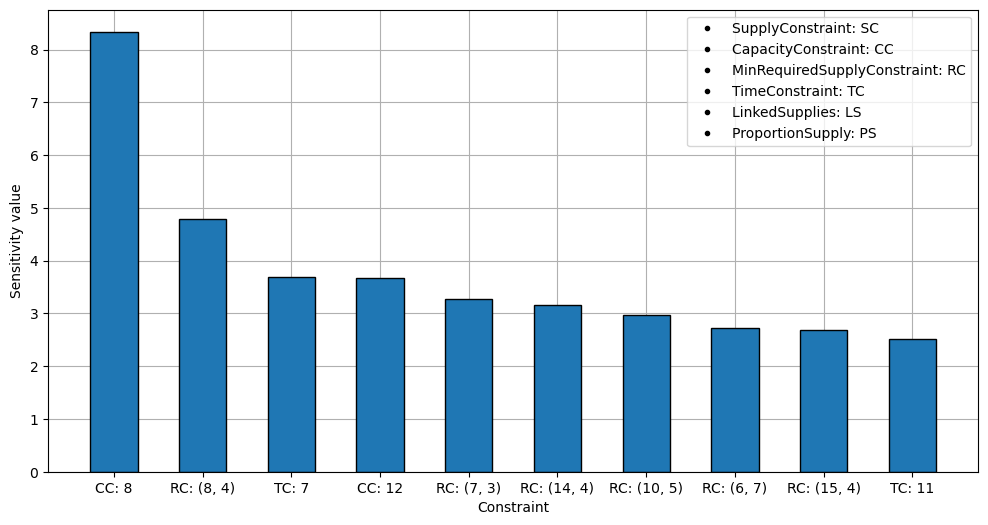

```python
fig = plt.figure(figsize=(12, 6))
plt.rc('axes', axisbelow=True)
x_positions = np.arange(len(top_10_index)) * 1.5
plt.bar(x_positions, top_10_dual, edgecolor='k', width=0.8)
plt.xticks(x_positions, top_10_index)
plt.xlabel('Constraint')
plt.ylabel('Sensitivity value')
plt.grid()

legend_patches = [plt.Line2D([0], [0], color='k', marker='.', linestyle='', label=f"{k}: {v}")
                  for k, v in dict_cons.items()]
plt.legend(handles=legend_patches,)
```

Using this figure, we can know on which of the constraint we should focus in. Also, this can be used as a method for knowing which infrastructure to improve in case of a natural disaster: by using the data for a city and the possible priorities after a natural disaster, this sensitivity analysis can provide the government the information of where is best to allocate the money, so not only this model could be used when an event has happened, but also to prevent damages.

## d) Dual model

*Formulate the dual associated with a), and implement and solve it in Pyomo. Does the Strong Duality Theorem holds? justify your answer.*

The variables associated with each of the original constraints will be:

- **Limit of supplies**: $ \sum_{i=1}^m x_{ij} \le S_j \ \rightarrow \ u_j \ge 0 $
- **Supply capacity**: $ \sum_{j=1}^n x_{ij} \le C_i \ \rightarrow \ w_i \ge 0 $
- **Minimum supplies required**: $ x_{ij} \ge R_{ij} \ \rightarrow \ y_{ij} \ge 0 $
- **Time limit**: $ t_i \sum_{j=1}^n x_{ij} \le L_i \ \rightarrow \ z_i \ge 0 $
- **Linked supplies**: $ x_{i3} - x_{i4} = 0 \ \rightarrow \ \mu_i \text{ free} $
- **Proportion of supply**: $ x_{i6} - 0.5 \sum_{j=1}^n x_{ij} <= 0 \ \rightarrow \nu _i \ge 0 $

The objective function for our dual model is then:

$$ \min \sum_{j=1}^n u_j S_j + \sum_{i=1}^m w_i C_i + \sum_{i=1}^m z_i L_i - \sum_{i=1}^m \sum_{j=1}^n y_{ij} R_{ij} $$

And the constraint is:

$$ u_j + w_i + t_i z_i - y_{ij} + \alpha_i + \beta_i \ge v_i^2 p_{ij} $$

where

$$ \alpha_i = \begin{cases} \mu_i \ ; \ j = 3 \\ - \mu_i \ ; \ j = 4 \\ 0 \ ; \ j \ne \{3, 4\} \end{cases} $$

and

$$ \beta_i = \begin{cases} \nu_i \ ; \ j = 6 \\ - \nu_i \ ; \ j \ne 6 \end{cases} $$

Solving the model:

```python
# Model
dual_model = ConcreteModel()

# Sets
dual_model.DISTRICTS = Set(initialize=range(1, m + 1))
dual_model.SUPPLIES = Set(initialize=range(1, n + 1))

# Parameters
dual_model.v = Param(model.DISTRICTS, initialize=v)
dual_model.p = Param(model.DISTRICTS, model.SUPPLIES, initialize=p)

dual_model.S = Param(model.SUPPLIES, initialize=S)
dual_model.C = Param(model.DISTRICTS, initialize=C)
dual_model.R = Param(model.DISTRICTS, model.SUPPLIES, initialize=R)
dual_model.t = Param(model.DISTRICTS, initialize=t)
dual_model.L = Param(model.DISTRICTS, initialize=L)

# Decision variables
dual_model.u = Var(dual_model.SUPPLIES, domain=NonNegativeReals)
dual_model.w = Var(dual_model.DISTRICTS, domain=NonNegativeReals)
dual_model.z = Var(dual_model.DISTRICTS, domain=NonNegativeReals)
dual_model.y = Var(dual_model.DISTRICTS, dual_model.SUPPLIES, domain=NonNegativeReals)
dual_model.mu = Var(dual_model.DISTRICTS, domain=Reals)
dual_model.nu = Var(dual_model.DISTRICTS, domain=NonNegativeReals)
```

```python
# Objective function
def objective_rule(model):
    #return sum((model.v[i])**2 * sum(model.p[i, j] * model.x[i, j] for j in model.SUPPLIES) for i in model.DISTRICTS)
    return sum(model.u[j] * model.S[j] for j in model.SUPPLIES) + sum(model.w[i] * model.C[i] for i in model.DISTRICTS) + sum(model.z[i] * model.L[i] for i in model.DISTRICTS) - sum(sum(model.y[i, j] * model.R[i, j] for j in model.SUPPLIES) for i in model.DISTRICTS)
dual_model.OBJ = Objective(rule=objective_rule, sense=minimize)
```

```python
def constraint1(model, i, j):
    term = model.u[j] + model.w[i] + model.t[i] * model.z[i] - model.y[i, j] + model.mu[i] * (1 if j == 3 else -1 if j == 4 else 0) + model.nu[i] * (1 if j == 6 else -1)

    return term >= model.v[i] ** 2 * model.p[i, j]

dual_model.Constraint1 = Constraint(dual_model.DISTRICTS, dual_model.SUPPLIES, rule=constraint1)
```

```python
# Solve
dual_model.dual = Suffix(direction=Suffix.IMPORT)
dual_solver = SolverFactory('glpk')  # Use GLPK as the solver
dual_results = dual_solver.solve(dual_model, tee=True)
```

```
GLPSOL--GLPK LP/MIP Solver 5.0
Parameter(s) specified in the command line:
 --write /var/folders/8g/6pyhwxxx6y147q2dm10zjk1w0000gn/T/tmpg0mv_sj4.glpk.raw
 --wglp /var/folders/8g/6pyhwxxx6y147q2dm10zjk1w0000gn/T/tmp1cp2j1ns.glpk.glp
 --cpxlp /var/folders/8g/6pyhwxxx6y147q2dm10zjk1w0000gn/T/tmphdggfyc2.pyomo.lp
Reading problem data from '/var/folders/8g/6pyhwxxx6y147q2dm10zjk1w0000gn/T/tmphdggfyc2.pyomo.lp'...
112 rows, 183 columns, 592 non-zeros
1261 lines were read
Writing problem data to '/var/folders/8g/6pyhwxxx6y147q2dm10zjk1w0000gn/T/tmp1cp2j1ns.glpk.glp'...
1159 lines were written
GLPK Simplex Optimizer 5.0
112 rows, 183 columns, 592 non-zeros
Preprocessing...
112 rows, 183 columns, 592 non-zeros
Scaling...
 A: min|aij| =  5.964e-01  max|aij| =  9.202e+00  ratio =  1.543e+01
Problem data seem to be well scaled
Constructing initial basis...
Size of triangular part is 112
      0: obj =   0.000000000e+00 inf =   4.414e+02 (112)
    126: obj =   3.910123082e+04 inf =   0.000e+00 (0) 1
*   237: obj =   2.021299206e+04 inf =   0.000e+00 (0)
OPTIMAL LP SOLUTION FOUND
Time used:   0.0 secs
Memory used: 0.2 Mb (261997 bytes)
Writing basic solution to '/var/folders/8g/6pyhwxxx6y147q2dm10zjk1w0000gn/T/tmpg0mv_sj4.glpk.raw'...
304 lines were written
```

```python
if dual_results.solver.status == SolverStatus.ok and dual_results.solver.termination_condition == TerminationCondition.optimal:
    print("Solver found an optimal solution.")
else:
    print("Solver did not find an optimal solution.")
```

```
Solver found an optimal solution.
```

### Strong Duality Theorem

To check if the Strong Duality Theorem holds, we extract the objective functions values and compare them:

```python
if value(model.OBJ) == value(dual_model.OBJ):
    print(f'The values are equal, so the Strong Duality Theorem holds: {value(model.OBJ)} = {value(dual_model.OBJ)}.')
else:
    print(f'The values are not equal, so the Strong Duality Theorem does not hold: {value(model.OBJ)} and {value(dual_model.OBJ)}.')
```

```
The values are equal, so the Strong Duality Theorem holds: 20212.99205668889 = 20212.99205668889.
```

And we can check individually each of the values of the dual model variables and compare them with the dual values calculated in c). For example, here we have the values for $ y_{ij} $ and they have, of course, the same module as the sensitivities calculated before:

```python
# y_{ij}
dual_data = []
for i in dual_model.DISTRICTS:
    for j in dual_model.SUPPLIES:
        dual_data.append({'District': i, 'Supply': j, 'y_ij': value(dual_model.y[i, j])})
dual_df = pd.DataFrame(dual_data)
pivot_dual_df = dual_df.pivot(index='District', columns='Supply', values='y_ij')
pivot_dual_df
```

| Supply District | 1 | 2 | 3 | 4 | 5 | 6 | 7 |
| --- | --- | --- | --- | --- | --- | --- | --- |
| 1 | 0.39 | 1.34 | 0.00 | 1.99 | 0.24 | 0.33 | 0.00e+00 |
| 2 | 1.02 | 0.20 | 1.86 | 0.00 | 0.00 | 1.17 | 7.47e-01 |
| 3 | 0.43 | 0.71 | 0.00 | 2.18 | 0.00 | 2.17 | 9.75e-03 |
| 4 | 0.00 | 1.06 | 0.00 | 0.84 | 1.07 | 1.79 | 1.78e+00 |
| 5 | 0.00 | 0.68 | 0.11 | 0.33 | 0.87 | 0.00 | 0.00e+00 |
| 6 | 0.97 | 0.00 | 0.00 | 0.62 | 0.88 | 0.00 | 2.73e+00 |
| 7 | 1.40 | 1.19 | 3.28 | 0.00 | 1.83 | 1.22 | 0.00e+00 |
| 8 | 1.96 | 1.94 | 0.00 | 4.78 | 0.00 | 0.99 | 1.12e+00 |
| 9 | 1.11 | 0.35 | 1.94 | 0.00 | 0.00 | 0.47 | 5.85e-01 |
| 10 | 0.58 | 0.00 | 2.50 | 0.00 | 2.98 | 1.94 | 2.11e+00 |
| 11 | 0.90 | 0.00 | 0.85 | 0.00 | 0.35 | 0.67 | 3.49e-02 |
| 12 | 0.85 | 1.23 | 1.26 | 0.65 | 1.23 | 0.61 | 0.00e+00 |
| 13 | 0.60 | 0.90 | 0.00 | 0.00 | 1.11 | 1.19 | 1.08e+00 |
| 14 | 0.47 | 0.00 | 0.00 | 3.16 | 1.18 | 0.00 | 7.55e-01 |
| 15 | 0.00 | 0.24 | 0.00 | 2.69 | 0.64 | 0.96 | 1.56e+00 |
| 16 | 0.00 | 0.00 | 0.00 | 0.00 | 0.00 | 0.00 | 0.00e+00 |

## e) Binary problem

*Modify the problem in a) to impose some logical or conditional (linear) constraints that require the use of binary variables Implement and solve this new model in Pyomo and interpret the results. Include the data used for the solution of the problem.*

We are going to create a problem similar to the one that we have solved, but in this case we want to know whether to send supplies $j$ to district $i$ or not, so we will use binary decision variables. We will also create some different constraints so we can explore their effects.

### Formulation of the problem

**Objective function**:

It will be the same one as before,

$$ \text{max} \sum_{i=1}^m v_i^2 \sum_{j=1}^n p_{ij}x_{ij} $$

, but this time $ x_{ij} \in \{ 0, 1 \} $, where $ x_{ij} = 1 $ if supply $j$ has to be sent to district $i$ and $ x_{ij} = 0 $ if not.

**Constraints**:

- **Limit of supplies**: $ \sum_{i=1}^m x_{ij} \le S_j \ \ , \ \ S_j \in [10, 16] $. There is a limit of districts that we can send the supply $j$ to.
- **Costs limit**: $ \sum_{i=1}^m \sum_{j=1}^n c_{ij} x_{ij} \le B = 20 $. Taking supply $j$ to district $i$ takes a certain cost $c_{ij}$ (for example, time), and there is a total limit $B$. This can be adapted to several type of real life constraints.
- **Linked supplies**: $ x_{i3} = x_{i4} $. Supplies 3 and 4 are again linked together.
- **Required supplies**: $ x_{ij} \ge R_{ij} $. There is a small probability (10%) that a district $i$ must need the supply $j$.

### Solving the model

Solve the model following the previous steps:

```python
# Random seed
random.seed(42)

# Generate data
S = {j: random.randint(10, m) for j in range(1, n + 1)}
c = {(i, j): random.uniform(0, 1) for i in range(1, m + 1) for j in range(1, n + 1)}
B = 20
R = {(i, j): random.choices([0, 1], [0.9, 0.1])[0] for i in range(1, m + 1) for j in range(1, n + 1)}
```

```python
# Model
model = ConcreteModel()

# Sets
model.DISTRICTS = Set(initialize=range(1, m + 1))
model.SUPPLIES = Set(initialize=range(1, n + 1))

# Parameters
model.v = Param(model.DISTRICTS, initialize=v)
model.p = Param(model.DISTRICTS, model.SUPPLIES, initialize=p)

model.S = Param(model.SUPPLIES, initialize=S)
model.c = Param(model.DISTRICTS, model.SUPPLIES, initialize=c)
model.R = Param(model.DISTRICTS, model.SUPPLIES, initialize=R)

# Decision variables
model.x = Var(model.DISTRICTS, model.SUPPLIES, domain=Binary)  # Binary variables!
```

```python
# Objective function
def objective_rule(model):
    return sum((model.v[i])**2 * sum(model.p[i, j] * model.x[i, j] for j in model.SUPPLIES) for i in model.DISTRICTS)
model.OBJ = Objective(rule=objective_rule, sense=maximize)
```

```python
# Constraint 1: Limit of supplies
def constraint1(model, j):
    return sum(model.x[i, j] for i in model.DISTRICTS) <= model.S[j]
model.Constraint1 = Constraint(model.SUPPLIES, rule=constraint1)

# Constraint 2: Cost limit
def constraint2(model):
    return sum(sum(model.c[i, j] * model.x[i, j] for j in model.SUPPLIES) for i in model.DISTRICTS) <= B
model.Constraint2 = Constraint(rule=constraint2)

# Constraint 3: Linked supplies
def constraint3(model, i, j):
    return model.x[i, j] >= model.R[i, j]
model.Constraint3 = Constraint(model.DISTRICTS, model.SUPPLIES, rule=constraint3)

# Constraint 4: Required supplies
def constraint4(model, i):
    return model.x[i, 3] == model.x[i, 4]
model.Constraint4 = Constraint(model.DISTRICTS, rule=constraint4)
```

```python
# Solve
model.dual = Suffix(direction=Suffix.IMPORT)
solver = SolverFactory('glpk')  # Use GLPK as the solver
results = solver.solve(model, tee=True)
```

```
GLPSOL--GLPK LP/MIP Solver 5.0
Parameter(s) specified in the command line:
 --write /var/folders/8g/6pyhwxxx6y147q2dm10zjk1w0000gn/T/tmpvyhubbg5.glpk.raw
 --wglp /var/folders/8g/6pyhwxxx6y147q2dm10zjk1w0000gn/T/tmpf14kpfky.glpk.glp
 --cpxlp /var/folders/8g/6pyhwxxx6y147q2dm10zjk1w0000gn/T/tmp32pyqi0f.pyomo.lp
Reading problem data from '/var/folders/8g/6pyhwxxx6y147q2dm10zjk1w0000gn/T/tmp32pyqi0f.pyomo.lp'...
/var/folders/8g/6pyhwxxx6y147q2dm10zjk1w0000gn/T/tmp32pyqi0f.pyomo.lp:1010: warning: lower bound of variable 'x2' redefined
/var/folders/8g/6pyhwxxx6y147q2dm10zjk1w0000gn/T/tmp32pyqi0f.pyomo.lp:1010: warning: upper bound of variable 'x2' redefined
136 rows, 112 columns, 368 non-zeros
112 integer variables, all of which are binary
1122 lines were read
Writing problem data to '/var/folders/8g/6pyhwxxx6y147q2dm10zjk1w0000gn/T/tmpf14kpfky.glpk.glp'...
851 lines were written
GLPK Integer Optimizer 5.0
136 rows, 112 columns, 368 non-zeros
112 integer variables, all of which are binary
Preprocessing...
2 hidden covering inequaliti(es) were detected
23 rows, 100 columns, 230 non-zeros
100 integer variables, all of which are binary
Scaling...
 A: min|aij| =  3.245e-03  max|aij| =  1.000e+00  ratio =  3.081e+02
GM: min|aij| =  2.431e-01  max|aij| =  4.114e+00  ratio =  1.692e+01
EQ: min|aij| =  6.120e-02  max|aij| =  1.000e+00  ratio =  1.634e+01
2N: min|aij| =  5.193e-02  max|aij| =  1.193e+00  ratio =  2.297e+01
Constructing initial basis...
Size of triangular part is 23
Solving LP relaxation...
GLPK Simplex Optimizer 5.0
23 rows, 100 columns, 230 non-zeros
*     0: obj =   4.922785329e+01 inf =   0.000e+00 (85)
*    46: obj =   2.919805855e+02 inf =   0.000e+00 (0)
OPTIMAL LP SOLUTION FOUND
Integer optimization begins...
Long-step dual simplex will be used
+    46: mip =     not found yet <=              +inf        (1; 0)
Solution found by heuristic: 291.622732535
+    63: mip =   2.916227325e+02 <=     tree is empty   0.0% (0; 19)
INTEGER OPTIMAL SOLUTION FOUND
Time used:   0.0 secs
Memory used: 0.2 Mb (187166 bytes)
Writing MIP solution to '/var/folders/8g/6pyhwxxx6y147q2dm10zjk1w0000gn/T/tmpvyhubbg5.glpk.raw'...
257 lines were written
```

```python
if results.solver.status == SolverStatus.ok and results.solver.termination_condition == TerminationCondition.optimal:
    print("Solver found an optimal solution.")
else:
    print("Solver did not find an optimal solution.")
```

```
Solver found an optimal solution.
```

We can easily visualize which district has to receive which supply by using a heatmap that assigns the color red to the value 0 and the color green to the value 1.

```python
data = []
for i in model.DISTRICTS:
    for j in model.SUPPLIES:
        data.append({'District': i, 'Supply': j, 'x_ij': value(model.x[i, j])})
df = pd.DataFrame(data)
pivot_df = df.pivot(index='District', columns='Supply', values='x_ij')
```

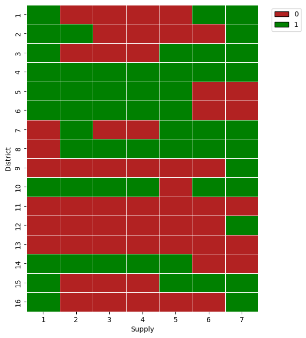

```python
plt.figure(figsize=(6, 8))
cmap = sns.color_palette(["firebrick", "g"])
sns.heatmap(pivot_df, cmap=cmap, cbar=False, linewidths=0.5)

legend_elements = [
    Patch(facecolor="firebrick", edgecolor="black", label="0"),
    Patch(facecolor="g", edgecolor="black", label="1")
]
plt.legend(handles=legend_elements, loc="upper right", bbox_to_anchor=(1.2, 1))
```

## f) Problem size vs. Computational time

*For the integer problem in e), solve several instances with diﬀerent sizes (diﬀerent numbers of variables and/or constraints) using randomly generated data. Graph the results (problem size vs computational time), and interpret them.*

We are going to scale the problem in e) so it has more districts and more supplies. This can easily happen in the case where we have bigger cities than Valencia or when we have details of the necessary supplies for zones smaller than districts, so we can have more precission to help those who need it the most.

To scale it, we are going to add the parameter $i$ to $m$ and $n$ and solve the binary problem for this $m, n$. This means that the quantity of decision variables will be given by $ (19 + i) (6 + i) = i^2 + 25i + 114 $.

```python
def binary_problem_variable_size(i):

    while True:

        time1 = time.time()

        #random.seed(42)

        m = 19 + i
        n = 6 + i

        # Generate random data
        v = {i: random.uniform(0, 1) for i in range(1, m + 1)}  # Index of vulnerability
        p = {(i, j): random.uniform(0, 1) for i in range(1, m + 1) for j in range(1, n + 1)}  # Priority

        S = {j: random.randint(1, m) for j in range(1, n + 1)}
        c = {(i, j): random.uniform(0, 1) for i in range(1, m + 1) for j in range(1, n + 1)}
        B = 20
        R = {(i, j): random.choices([0, 0], [0.9, 0.1])[0] for i in range(1, m + 1) for j in range(1, n + 1)}

        # Model
        model = ConcreteModel()

        # Sets
        model.DISTRICTS = Set(initialize=range(1, m + 1))
        model.SUPPLIES = Set(initialize=range(1, n + 1))

        # Parameters
        model.v = Param(model.DISTRICTS, initialize=v)
        model.p = Param(model.DISTRICTS, model.SUPPLIES, initialize=p)

        model.S = Param(model.SUPPLIES, initialize=S)
        model.c = Param(model.DISTRICTS, model.SUPPLIES, initialize=c)
        model.R = Param(model.DISTRICTS, model.SUPPLIES, initialize=R)

        # Decision variables
        model.x = Var(model.DISTRICTS, model.SUPPLIES, domain=Binary)

        # Objective function
        def objective_rule(model):
            return sum(
                (model.v[i])**2 * sum(model.p[i, j] * model.x[i, j] for j in model.SUPPLIES)
                for i in model.DISTRICTS
            )
        model.OBJ = Objective(rule=objective_rule, sense=maximize)

        #Constraints
        def constraint1(model, j):
            return sum(model.x[i, j] for i in model.DISTRICTS) <= model.S[j]
        model.Constraint1 = Constraint(model.SUPPLIES, rule=constraint1)

        def constraint2(model):
            return sum(sum(model.c[i, j] * model.x[i, j] for j in model.SUPPLIES) for i in model.DISTRICTS) <= B
        model.Constraint2 = Constraint(rule=constraint2)

        def constraint3(model, i, j):
            return model.x[i, j] >= model.R[i, j]
        model.Constraint3 = Constraint(model.DISTRICTS, model.SUPPLIES, rule=constraint3)

        def constraint4(model, i):
            return model.x[i, 3] == model.x[i, 4]
        model.Constraint4 = Constraint(model.DISTRICTS, rule=constraint4)

        # Solve
        solver = SolverFactory('glpk')
        results = solver.solve(model)

        # If it has not found an optimal solution, run again:
        if results.solver.status == SolverStatus.ok and results.solver.termination_condition == TerminationCondition.optimal:
            break
        else:
            continue

    time2 = time.time()

    return time2-time1
```

We will take 20 samples for each size so the results are more accurate.

```python
sample_number_time = 20
list_i = []
list_x = []
list_time = []

for i in range(0, 400, 25):
    list_i.append(i)
    list_x.append(i**2 + 25*i + 114)
    samples_time = []
    for _ in range(0, sample_number_time):
        samples_time.append(binary_problem_variable_size(i))
    list_time.append(sum(samples_time)/len(samples_time))
```

### $t$ vs. $i$

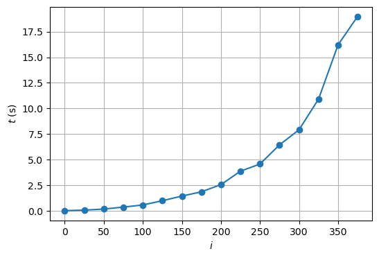

```python
plt.figure(figsize=(6, 4))
plt.plot(list_i, list_time, marker='o')
plt.xlabel('$i$')
plt.ylabel('$t$ (s)')
plt.grid()
```

We can see that increasing the parameter $i$ has a non linear relation with the time. Let's plot time vs. the number of decision variables ($i^2 + 25i + 114$), which increases with $i^2$.

### $t$ vs. $\#x_{ij}$

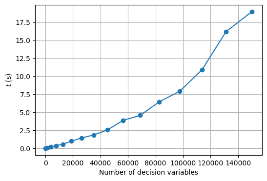

```python
plt.figure(figsize=(6, 4))
plt.plot(list_x, list_time, marker='o')
plt.xlabel('Number of decision variables')
plt.ylabel('$t$ (s)')
plt.grid()
```

As we see in the plot, the relation is not completely linear, as the slope increases a bit throughout the x-axis. However, it seems that when the number of variables is not too high (until around 60000) the relation can be approximately described as linear. In this model, solving time scalates nicely with the problem size, which can allow us to solve models for bigger cities with more details of their districts.

## g) Changing a parameter

*For the integer problem in e), solve several instances with the same data, using (10 to 20) diﬀerent values for one of the parameters in the model (choose a parameter you think may provide insights for the interpretation of the diﬀerent solution values). Collect the resulting optimal values of the objective function, print and plot them. Comment on these values.*

In our constraints for the binary problem, we have a costs limit of the form: $ \sum_{i=1}^m \sum_{j=1}^n c_{ij} x_{ij} \le B = 20 $. As this constraint is very interesting because many real life constraints can be expressed with this sum of weights, we are going to see how the values of the objective function change when we change this parameter $B$.

```python
def binary_problem_variable_parameter(B):

    random.seed(42)  # As we use the random seed, all data except B is going to be the same.

    m = 19
    n = 6

    # Generate data
    v = {i: random.uniform(0, 1) for i in range(1, m + 1)}  # Index of vulnerability
    p = {(i, j): random.uniform(0, 1) for i in range(1, m + 1) for j in range(1, n + 1)}  # Priority

    S = {j: random.randint(1, m) for j in range(1, n + 1)}
    c = {(i, j): random.uniform(0, 1) for i in range(1, m + 1) for j in range(1, n + 1)}
    # B = 20
    R = {(i, j): random.choices([0, 0], [0.9, 0.1])[0] for i in range(1, m + 1) for j in range(1, n + 1)}

    # Model
    model = ConcreteModel()

    # Sets
    model.DISTRICTS = Set(initialize=range(1, m + 1))
    model.SUPPLIES = Set(initialize=range(1, n + 1))

    # Parameters
    model.v = Param(model.DISTRICTS, initialize=v)
    model.p = Param(model.DISTRICTS, model.SUPPLIES, initialize=p)

    model.S = Param(model.SUPPLIES, initialize=S)
    model.c = Param(model.DISTRICTS, model.SUPPLIES, initialize=c)
    model.R = Param(model.DISTRICTS, model.SUPPLIES, initialize=R)

    # Decision variables
    model.x = Var(model.DISTRICTS, model.SUPPLIES, domain=Binary)

    # Objective function
    def objective_rule(model):
        return sum(
            (model.v[i])**2 * sum(model.p[i, j] * model.x[i, j] for j in model.SUPPLIES)
            for i in model.DISTRICTS
        )
    model.OBJ = Objective(rule=objective_rule, sense=maximize)

    #Constraints
    def constraint1(model, j):
        return sum(model.x[i, j] for i in model.DISTRICTS) <= model.S[j]
    model.Constraint1 = Constraint(model.SUPPLIES, rule=constraint1)

    def constraint2(model):
        return sum(sum(model.c[i, j] * model.x[i, j] for j in model.SUPPLIES) for i in model.DISTRICTS) <= B
    model.Constraint2 = Constraint(rule=constraint2)

    def constraint3(model, i, j):
        return model.x[i, j] >= model.R[i, j]
    model.Constraint3 = Constraint(model.DISTRICTS, model.SUPPLIES, rule=constraint3)

    def constraint4(model, i):
        return model.x[i, 3] == model.x[i, 4]
    model.Constraint4 = Constraint(model.DISTRICTS, rule=constraint4)

    # Solve
    solver = SolverFactory('glpk')
    solver.solve(model)

    return value(model.OBJ)
```

Again, we are going to take 20 samples for each value:

```python
sample_number_OBJ = 20
list_B = []
list_OBJ = []

for B in range(1, 25):
    list_B.append(B)
    samples_OBJ = []
    for _ in range(0, sample_number_OBJ):
        samples_OBJ.append(binary_problem_variable_parameter(B))
    list_OBJ.append(sum(samples_OBJ)/len(samples_OBJ))
```

Plotting them:

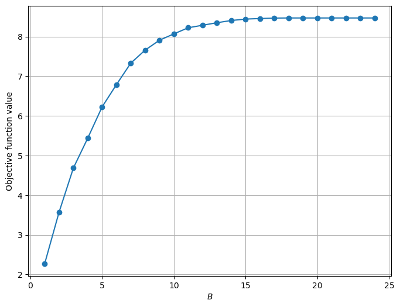

```python
plt.figure(figsize=(8, 6))
plt.plot(list_B, list_OBJ, marker='o')
plt.xlabel('$B$')
plt.ylabel('Objective function value')
plt.grid()
```

We can see how the objective function value changes with the parameter $B$, following a relation that plateaus at $B \approx 15$ with a value of $ \text{OBJ} \approx 8.5$. This means that increasing this limit will not give benefits (or they will be marginal) after this point, as the constraint is no longer relevant.

However, in real life increasing this parameter has a cost, but there is a point of maximum curvature from which we start getting deminishing returns. To automate the search for this point, which could be very useful for knowing up to which point we need to increase the limit, we can use the elbow method. For this, we could use a specialized python library like $\textsf{kneed}$ but, to avoid compatibility issues, we are going to plot a simple approximation to the elbow point that maximizes the distance to a line from the first to the last point:

```
The optimum value for parameter B is 8.
```

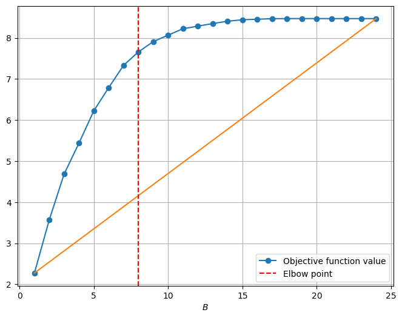

```python
line = np.linspace(list_OBJ[len(list_OBJ)-1], list_OBJ[0], 24)
difference = list_OBJ - line[::-1]
index_optimum_B = np.argmax(difference)
optimum_B = list_B[index_optimum_B]

print(f"The optimum value for parameter B is {optimum_B}.")

plt.figure(figsize=(8, 6))
plt.plot(list_B, list_OBJ, marker='o', label='Objective function value')
plt.plot(list_B, line[::-1], linestyle='-')
plt.axvline(x=optimum_B, color='red', linestyle='--', label='Elbow point')
plt.xlabel('$B$')
plt.legend()
plt.grid()
```

This means that having a $B=8$ will give us most of the benefit. From this point until $B \approx 15$, there will be benefits but they will not make such an impact and, from there, we can not obtain more benefits from increasing $B$.